# 201.5. DiaSource table

For the Rubin Science Platform at data.lsst.cloud.  
Data Release: [Data Preview 2](https://dp2.lsst.io/)  
Container Size: Large  
LSST Science Pipelines version: r30.0.10  
Last verified to run: 2026-07-22  
Repository: github.com/lsst/tutorial-notebooks  
DOI: 10.11578/rubin/dc.20250909.20

**Learning objective:** To understand the contents of the `DiaSource` table and how to access it.

**LSST data products:** `DiaSource`

**Packages:** `lsst.rsp`, `lsst.daf.butler`

**Credit:** Originally developed by the Rubin Community Science team with feedback from Eric Bellm, Federica Bianco, and Tatiana Cuellar. Please consider acknowledging them if this notebook is used for the preparation of journal articles, software releases, or other notebooks.

**Get Support:** Everyone is encouraged to ask questions or raise issues in the [Support Category](https://community.lsst.org/c/support) of the Rubin Community Forum. Rubin staff will respond to all questions posted there.

## 1. Introduction

The `DiaSource` table contains measurements for positive- and negative-flux sources detected in the difference images with signal-to-noise ratio $\geq5$.

**Related tutorials:** The TAP and butler data access services are demonstrated in the 100-level "How to" tutorials. There are 200-level tutorials on `difference_images` and `DiaObjects`.

### 1.1. Import packages

Import standard python packages `numpy`, `matplotlib` and `astropy`.

From the `lsst` package, import modules for the TAP service, the butler, and plotting.

```python
import re
import numpy as np
import matplotlib.pyplot as plt
from lsst.rsp import RSPDiscovery
from lsst.daf.butler import Butler
from lsst.utils.plotting import (get_multiband_plot_colors,
                                 get_multiband_plot_symbols)
```

### 1.2. Define parameters and functions

Create an instance of the TAP service, and assert that it exists.

```python
discovery = RSPDiscovery("dp2")
tap_service = discovery.get_tap_client()
```

Create an instance of the Rubin data butler, and assert that it exists.

```python
butler = Butler("dp2", collections="dp2")
```

Define the colors and symbols to represent the LSST filters in plots.

```python
filter_colors = get_multiband_plot_colors()
filter_names = filter_colors.keys()
filter_symbols = get_multiband_plot_symbols()
```

## 2. Schema (columns)

To browse the table schema visit the [Rubin schema browser](https://sdm-schemas.lsst.io/), or use the TAP service via the Portal Aspect or as demonstrated in Section 2.1.

### 2.1. Retrieve table schema

To retrieve the table schema, define a query for the schema columns of the `DiaSource` table and run the query job.

```python
query = "SELECT column_name, datatype, description, unit " \
        "FROM tap_schema.columns " \
        "WHERE table_name = 'dp2.DiaSource'"
job = tap_service.submit_job(query)
job.run()
job.wait(phases=['COMPLETED', 'ERROR'])
print('Job phase is', job.phase)
if job.phase == 'ERROR':
    job.raise_if_error()
assert job.phase == 'COMPLETED'
```

```
Job phase is COMPLETED
```

Retrieve the query results and display them as an `astropy` table with the `to_table()` attribute.

```python
results = job.fetch_result().to_table()
results
```

*Table length=90*

| column_name str64 | datatype str64 | description str512 | unit str64 |
| --- | --- | --- | --- |
| diaSourceId | long | Unique identifier of this DiaSource. |  |
| visit | long | Id of the visit where this diaSource was measured. |  |
| detector | short | Id of the detector where this diaSource was measured. |  |
| diaObjectId | long | Id of the diaObject this source was associated with, if any. If not, it is set to 0 |  |
| ssObjectId | long | Id of the ssObject this source was associated with, if any. If not, it is set to 0 |  |
| parentDiaSourceId | long | Id of the parent diaSource this diaSource has been deblended from, if any. |  |
| midpointMjdTai | double | Effective mid-visit time for this diaSource, expressed as Modified Julian Date, International Atomic Time. | d |
| ra | double | Right ascension coordinate of the center of this diaSource. | deg |
| dec | double | Declination coordinate of the center of this diaSource. | deg |
| raErr | float | Angular error in right ascension (∂RA*cos(Dec)). | deg |
| decErr | float | Error in declination. | deg |
| ra_dec_Cov | float | Covariance between right ascension (RA*cos(Dec)) and declination. | deg**2 |
| x | double | Unweighted first moment centroid, overall centroid. | pixel |
| xErr | float | 1-sigma uncertainty on x position. | pixel |
| y | double | Unweighted first moment centroid, overall centroid. | pixel |
| yErr | float | 1-sigma uncertainty on y position. | pixel |
| centroid_flag | boolean | General centroid algorithm failure flag; set if anything went wrong when fitting the centroid. Another centroid flag field should also be set to provide more information. |  |
| apFlux | float | Flux in a 12 pixel radius aperture on the difference image. | nJy |
| apFluxErr | float | Estimated uncertainty of apFlux. | nJy |
| apFlux_flag | boolean | General aperture flux algorithm failure flag; set if anything went wrong when measuring aperture fluxes. Another apFlux flag field should also be set to provide more information. |  |
| apFlux_flag_apertureTruncated | boolean | Aperture did not fit within measurement image. |  |
| isNegative | boolean | Source was detected as significantly negative. |  |
| ... | ... | ... | ... |
| bboxSize | long | Size of the square bounding box that fully contains the detection footprint. | pixel |
| pixelFlags | boolean | General pixel flags failure; set if anything went wrong when setting pixels flags from this footprint's mask. This implies that some pixelFlags for this source may be incorrectly set to False. |  |
| pixelFlags_bad | boolean | Bad pixel in the DiaSource footprint. |  |
| pixelFlags_cr | boolean | Cosmic ray in the DiaSource footprint. |  |
| pixelFlags_crCenter | boolean | Cosmic ray in the 3x3 region around the centroid. |  |
| pixelFlags_edge | boolean | Some of the source footprint is outside usable exposure region (masked EDGE or centroid off image). |  |
| pixelFlags_nodata | boolean | NO_DATA pixel in the source footprint. |  |
| pixelFlags_nodataCenter | boolean | NO_DATA pixel in the 3x3 region around the centroid. |  |
| pixelFlags_interpolated | boolean | Interpolated pixel in the DiaSource footprint. |  |
| pixelFlags_interpolatedCenter | boolean | Interpolated pixel in the 3x3 region around the centroid. |  |
| pixelFlags_offimage | boolean | DiaSource center is off image. |  |
| pixelFlags_saturated | boolean | Saturated pixel in the DiaSource footprint. |  |
| pixelFlags_saturatedCenter | boolean | Saturated pixel in the 3x3 region around the centroid. |  |
| pixelFlags_suspect | boolean | DiaSource's footprint includes suspect pixels. |  |
| pixelFlags_suspectCenter | boolean | Suspect pixel in the 3x3 region around the centroid. |  |
| pixelFlags_streak | boolean | Streak in the DiaSource footprint. |  |
| pixelFlags_streakCenter | boolean | Streak in the 3x3 region around the centroid. |  |
| pixelFlags_injected | boolean | Injection in the DiaSource footprint. |  |
| pixelFlags_injectedCenter | boolean | Injection in the 3x3 region around the centroid. |  |
| pixelFlags_injected_template | boolean | Template injection in the DiaSource footprint. |  |
| pixelFlags_injected_templateCenter | boolean | Template injection in the 3x3 region around the centroid. |  |
| glint_trail | boolean | This flag is set if the source is part of a glint trail. |  |

The table displayed above has been truncated.

Option to print every column name as a list.

```python
# for col in results['column_name']:
#     print(col)
```

Option to use the regular expressions package `re` to search for column names that contain the string `temp`.

```python
# temp = 'Err'
# temp = 'Flux'
# temp = 'psf'
# for col in results['column_name']:
#     if re.search(temp, col):
#         print(col)
```

Delete the job, but not the `results`.

```python
del query
job.delete()
```

### 2.2. Key columns

#### 2.2.1. Identifiers

A long integer that uniquely identifies each row of the `DiaSource` table.

- `diaSourceId`

The long integers that identify the associated `diaObject` or `ssObject`; only one of these two will be populated.

- `diaObjectId`
- `ssObjectId`

#### 2.2.2. Visit information

- `visit`
- `detector`

The filter band used for the observation of the `DiaSource`.

- `band`

Effective mid-exposure time for visit where the `DiaSource` was detected, expressed as Modified Julian Date, International Atomic Time.

- `midpointMjdTai`

#### 2.2.3. Coordinates

The sky coordinates in decimal degrees for each `DiaSource`:

- `ra`, `raErr`
- `dec`, `decErr`

#### 2.2.4. Flux measurements and flags

Fluxes are provided in nanoJanskys, which is preferred for difference-image photometry over magnitudes since negative flux measurements would be omitted when converting to magnitudes.

**PSF fluxes**

A forced fit of the Point Spread Function (PSF) at the diaSource's coordinates in each difference image. PSF fluxes are best to use for point-like sources.

- `psfFlux`, `psfFluxErr`

Note that in the `DiaSource` table, the `psfFlux` column contains fluxes measured on the difference image. In other tables `psfFlux` is a flux on the direct (science) image.

**Other fluxes**

- `apFlux`: fluxes in a 12 pixel radius aperture on the `difference_image`.
- `scienceFlux`: Forced PSF flux measured on the direct `visit_image`.

**Flags**

A variety of flags indicating whether pixels that are saturated, or affected by cosmic rays, contributed to the diaSource's measurements.

- `pixelFlags_*`

The flux (and shape) measurements mentioned above have associated flag columns suffixed with `_flag`.

- `_flag`

A boolean flag indicating whether or not the `diaSource` is classified as a dipole: , a likely image-differencing artifact that appears as offset positive and negative lobes. Setting this to `False` will filter out poorly subtracted stars.

- `isDipole`

#### 2.2.5. Reliability score

The purpose of the `reliability` score in the `DiaSource` table is to provide a threshold measure to improve the purity of DIA detections.

For DP2, the `reliability` score accidentally used the v0.1 model, the same model that was used for DP1. Unfortunately this means that none of the advances made on reliability scoring that are documented in [DMTN-337](https://dmtn-337.lsst.io/) were applied to DP2. As no reliability-based cuts were made to the catalog contents this ultimately has not impacted the `DiaSource` table, except that the reliability scores are not as informative as they could be.

- `reliability`

### 2.3. Descriptions and units

For a subset of the key columns show the table of their descriptions and units.

```python
col_list = set(['diaSourceId', 'diaObjectId', 'ssObjectId', 'band', 'visit',
                'midpointMjdTai', 'ra', 'dec', 'psfFlux', 'psfFluxErr', 'isDipole'])
tx = [i for i, item in enumerate(results['column_name']) if item in col_list]
results[tx]
```

*Table length=11*

| column_name str64 | datatype str64 | description str512 | unit str64 |
| --- | --- | --- | --- |
| diaSourceId | long | Unique identifier of this DiaSource. |  |
| visit | long | Id of the visit where this diaSource was measured. |  |
| diaObjectId | long | Id of the diaObject this source was associated with, if any. If not, it is set to 0 |  |
| ssObjectId | long | Id of the ssObject this source was associated with, if any. If not, it is set to 0 |  |
| midpointMjdTai | double | Effective mid-visit time for this diaSource, expressed as Modified Julian Date, International Atomic Time. | d |
| ra | double | Right ascension coordinate of the center of this diaSource. | deg |
| dec | double | Declination coordinate of the center of this diaSource. | deg |
| psfFlux | float | Flux for Point Source model. Note this actually measures the flux difference between the template and the visit image. | nJy |
| psfFluxErr | float | Uncertainty of psfFlux. | nJy |
| band | char | Filter band this source was observed with. |  |
| isDipole | boolean | Source well fit by a dipole. |  |

Clean up.

```python
del col_list, tx, results
```

## 3. Data access

The `DiaSource` table is available via the TAP service and the butler.

**Recommended access method:** TAP.

### 3.1. Advisory: avoid full-table queries

**Avoid full-table queries. It is ideal to constrain queries by `diaObjectId` or `ssObjectId`, or by visit/detector.**

Most queries on the `DiaSource` table should be for all difference-image detections associated with a given diaObject, ssObject, or visit and detector. For the question of *"did Rubin ever detect a time-domain object at this RA, Dec?"*, query the `DiaObject` table, then get all diaSources associated with that diaObject with a separate query (or use a table join, as in S.3.3.2.).

### 3.2. Advisory: not recommended for light curves

**The `ForcedSourceOnDiaObject` table is recommended for light curves.**

The `DiaSource` table contains measurements of difference-image sources with $\geq5\sigma$ detections, which means that lower-flux variability will not be captured. The `ForcedSourceOnDiaObject` table, which contains forced PSF photometry for *all* difference images as well as non-difference (i.e. `visit`) images, is recommended to generate complete variable and transient object light curves, with a data point for every time the coordinates were observed.

### 3.3. TAP (Table Access Protocol)

The `DiaSource` table is stored in Qserv and accessible via the TAP services using ADQL queries.

**Including spatial constraints:** Qserv stores catalog data sharded by coordinate (RA, Dec), so ADQL query statements that include constraints by coordinate do not requre a whole-catalog search and are typically faster (and can be much faster) than ADQL query statements which only include constraints for other columns. Use either an ADQL cone or polygon search for faster queries (do not use `WHERE ... BETWEEN` statements to set boundaries on RA and Dec).

#### 3.3.1. Demo query

Define a query to return the "key columns" from Section 2.3.

Impose **visit and detector** constraints: create a query to return all diaSources detected in the difference image corresponding to detector number 86, visit number 2026010500067. This is not a special image, just a random example.

```python
visit = 2026010500067
detector = 86
```

```python
query = """SELECT diaSourceId, diaObjectId, ssObjectId, band, visit, detector,
        midpointMjdTai, ra, dec, psfFlux, psfFluxErr, isDipole
        FROM dp2.DiaSource
        WHERE visit = {} AND detector = {}""".format(visit, detector)
print(query)
```

```
SELECT diaSourceId, diaObjectId, ssObjectId, band, visit, detector,
        midpointMjdTai, ra, dec, psfFlux, psfFluxErr, isDipole
        FROM dp2.DiaSource
        WHERE visit = 2026010500067 AND detector = 86
```

```python
job = tap_service.submit_job(query)
job.run()
job.wait(phases=['COMPLETED', 'ERROR'])
print('Job phase is', job.phase)
if job.phase == 'ERROR':
    job.raise_if_error()
```

```
Job phase is COMPLETED
```

Fetch the results as an `astropy` table.

```python
assert job.phase == 'COMPLETED'
results = job.fetch_result().to_table()
print(len(results))
```

```
23
```

Option to display the table.

```python
# results
```

Plot the coordinates for each diaSource detection, and the histogram of psfFlux values.

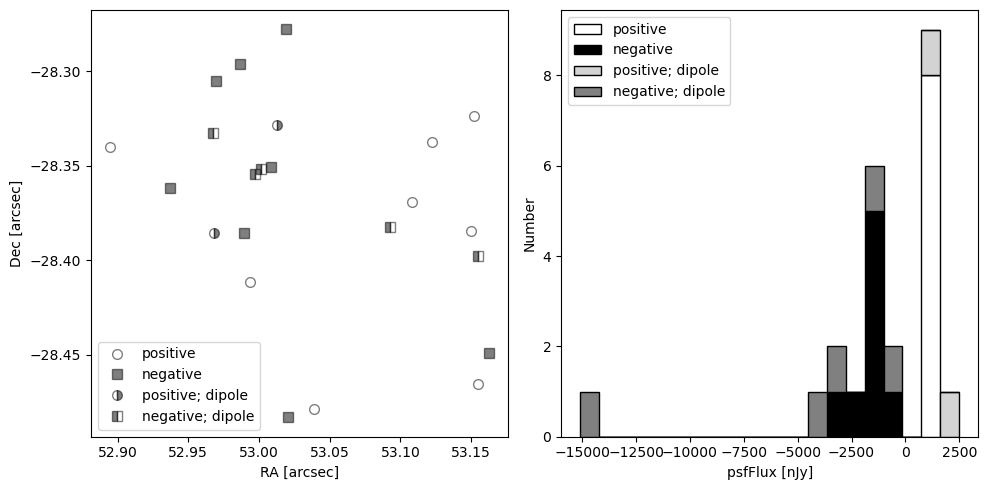

```python
fig, ax = plt.subplots(1, 2, figsize=(10, 5))
tx1 = np.where((results['psfFlux'] > 0.0) & (~results['isDipole']))[0]
tx2 = np.where((results['psfFlux'] < 0.0) & (~results['isDipole']))[0]
tx3 = np.where((results['psfFlux'] > 0.0) & (results['isDipole']))[0]
tx4 = np.where((results['psfFlux'] < 0.0) & (results['isDipole']))[0]
ax[0].plot(results['ra'][tx1], results['dec'][tx1], 'o', fillstyle='full', color='white',
           ms=7, mew=1, mec='black', alpha=0.5, label='positive')
ax[0].plot(results['ra'][tx2], results['dec'][tx2], 's', fillstyle='full', color='black',
           ms=7, mew=1, mec='black', alpha=0.5, label='negative')
ax[0].plot(results['ra'][tx3], results['dec'][tx3], 'o', fillstyle='right', color='black',
           ms=7, mew=1, mec='black', alpha=0.5, label='positive; dipole')
ax[0].plot(results['ra'][tx4], results['dec'][tx4], 's', fillstyle='left', color='black',
           ms=7, mew=1, mec='black', alpha=0.5, label='negative; dipole')
ax[0].set_xlabel('RA [arcsec]')
ax[0].set_ylabel('Dec [arcsec]')
ax[0].legend(loc='lower left')
bar_data = [results['psfFlux'][tx1], results['psfFlux'][tx2],
            results['psfFlux'][tx3], results['psfFlux'][tx4]]
bar_colors = ['white', 'black', 'lightgrey', 'grey']
bar_labels = ['positive', 'negative', 'positive; dipole', 'negative; dipole']
ax[1].hist(bar_data, bins=20, stacked=True, color=bar_colors, edgecolor='black', label=bar_labels)
ax[1].set_xlabel('psfFlux [nJy]')
ax[1].set_ylabel('Number')
ax[1].legend(loc='upper left')
plt.tight_layout()
plt.show()
del tx1, tx2, tx3, tx4
```

> **Figure 1:** At left, the RA and Dec for all detected diaSources in the chosen visit+detector, with symbol type and color fill representing positive or negative flux, and whether the source exhibited a dipole morphology. At right, a stacked bar chart of the difference-image PSF flux measurements for detected diaSources.

Clean up.

```python
job.delete()
del query, results
```

#### 3.3.2. Joinable tables

The `DiaSource` table can be joined to the `DiaObject` table on the column containing the unique `diaObjectId`, and with the `SSObject` table on `ssObjectId`.

**DiaObject Table**

The `DiaObject` table contains statistical information from `DiaSource` properties associated with the DiaObject.

As an example, query for all the diaSources (difference-image detections) associated with all diaObjects within 5 arcseconds of the target coordinates (e.g., a potential host galaxy of interest). Return the `diaSourceId`, `psfFlux`, and `band` from the `DiaSource` table, and the `diaObjectId` and the number of detections `nDiaSources` from the `DiaObject` table.

```python
ra_targ = 151.591891
dec_targ = 1.159049
search_radius = np.round(5./3600.0, 5)
query = """SELECT dias.diaSourceId, dias.psfFlux, dias.band,
        diao.diaObjectId, diao.nDiaSources
        FROM dp2.DiaSource AS dias
        JOIN dp2.DiaObject AS diao ON dias.diaObjectId = diao.diaObjectId
        WHERE CONTAINS(POINT('ICRS', diao.ra, diao.dec),
        CIRCLE('ICRS', {}, {}, {})) = 1""".format(ra_targ, dec_targ, search_radius)
print(query)
```

```
SELECT dias.diaSourceId, dias.psfFlux, dias.band,
        diao.diaObjectId, diao.nDiaSources
        FROM dp2.DiaSource AS dias
        JOIN dp2.DiaObject AS diao ON dias.diaObjectId = diao.diaObjectId
        WHERE CONTAINS(POINT('ICRS', diao.ra, diao.dec),
        CIRCLE('ICRS', 151.591891, 1.159049, 0.00139)) = 1
```

```python
job = tap_service.submit_job(query)
job.run()
job.wait(phases=['COMPLETED', 'ERROR'])
print('Job phase is', job.phase)
if job.phase == 'ERROR':
    job.raise_if_error()
```

```
Job phase is COMPLETED
```

Fetch the results as an `astropy` table.

```python
assert job.phase == 'COMPLETED'
results = job.fetch_result().to_table()
```

Option to display the results.

```python
# results
```

For each unique diaObject within the search radius, print the number of rows (detections) returned from the `DiaSource` table.

```python
values, counts = np.unique(results['diaObjectId'], return_counts=True)
for value, count in zip(values, counts):
    print(value, count)
```

```
786352299365629972 201
786352299365630545 1
786352299365631347 1
786352299365631545 1
786352299365632044 1
```

Print the number of detections per band.

```python
use_diaObjectId = 786352299365629972
print("For diaObjectId: ", use_diaObjectId)

tx = np.where(results['diaObjectId'] == 786352299365629972)[0]
print('Total number of detections: ', results['nDiaSources'][tx[0]])

string_out = 'Number of detections per filter:  '
for f, filt in enumerate(filter_names):
    fx = np.where(results['band'][tx] == filt)[0]
    string_out += filt + ': ' + str(len(fx)) + '   '
    del fx
print(string_out)
del use_diaObjectId, tx, string_out
```

```
For diaObjectId:  786352299365629972
Total number of detections:  201
Number of detections per filter:  u: 24   g: 19   r: 67   i: 61   z: 27   y: 3
```

```python
del query, results
```

**SSObject Table**

The `DiaSource` table can also be joined to the `SSObject` table on the column containing the unique `ssObjectId`.

As an example, query for all the diaSources (difference-image detections) associated with the ssObject with the designation (name) "2001 HL69". Return the `diaSourceId`, `psfFlux`, and `band` from the `DiaSource` table, and the `ssObjectId`, the `nObs` (number of observations), and the `designation` from the `SSObject` table.

```python
use_designation = '2001 HL69'
query = """SELECT dias.diaSourceId, dias.psfFlux, dias.band,
        sso.ssObjectId, sso.nObs, sso.designation
        FROM dp2.DiaSource AS dias
        JOIN dp2.SSObject AS sso ON dias.ssObjectId = sso.ssObjectId
        WHERE sso.designation = '{}'""".format(use_designation)
print(query)
```

```
SELECT dias.diaSourceId, dias.psfFlux, dias.band,
        sso.ssObjectId, sso.nObs, sso.designation
        FROM dp2.DiaSource AS dias
        JOIN dp2.SSObject AS sso ON dias.ssObjectId = sso.ssObjectId
        WHERE sso.designation = '2001 HL69'
```

```python
job = tap_service.submit_job(query)
job.run()
job.wait(phases=['COMPLETED', 'ERROR'])
print('Job phase is', job.phase)
if job.phase == 'ERROR':
    job.raise_if_error()
assert job.phase == 'COMPLETED'
results = job.fetch_result().to_table()
print(len(results))
```

```
Job phase is COMPLETED
587
```

Show that only one unique ssObject was returned (the one requested by name).

```python
print(np.unique(results['ssObjectId'])[0])
print(np.unique(results['designation'])[0])
```

```
21163611476343116
2001 HL69
```

Print the number of detections per band.

```python
string_out = 'Number of detections per filter:  '
for f, filt in enumerate(filter_names):
    fx = np.where(results['band'] == filt)[0]
    string_out += filt + ': ' + str(len(fx)) + '   '
    del fx
print(string_out)
del string_out

print('Total number of detections: ', results['nObs'][0])
```

```
Number of detections per filter:  u: 26   g: 187   r: 232   i: 142   z: 0   y: 0
Total number of detections:  587
```

Clean up.

```python
job.delete()
del query, results
```

### 3.4. Butler

TAP is the recommended way to access the `diaSource` table, but the butler is a convenient way to retrive all `diaSources` detected in a given tract.

Show that the dimension for the `dia_source` table is just the skymap's tract, and that it is required.

```python
butler.get_dataset_type('dia_source')
```

```
DatasetType('dia_source', {skymap, tract}, ArrowAstropy)
```

```python
butler.get_dataset_type('dia_source').dimensions.required
```

```
{skymap, tract}
```

#### 3.4.1. Demo query

Retrieve the dataset references (`refs`) for `dia_source` tables for tracts that overlap the coordinates near the center of the COSMOS field. There will be only 1.

```python
ra_center = 150.1
dec_center = 2.1
refs = butler.query_datasets("dia_source",
                             where="tract.region OVERLAPS POINT(:ra, :dec)",
                             bind={"ra": ra_center, "dec": dec_center},
                             order_by='tract')
print(len(refs))
```

```
1
```

Define a subset of columns to retrieve from the butler, and retrieve the table data.

```python
col_list = set(['diaSourceId', 'band', 'midpointMjdTai',
                'ra', 'dec', 'psfFlux', 'psfFluxErr'])
results = butler.get(refs[0], parameters={'columns': col_list})
print(len(results))
```

```
891511
```

Subset the results to r-band fluxes between 20 and 25 mag.

```python
tx = np.where((results['psfFlux'] > 360.0)
              & (results['psfFlux'] <= 36000.0)
              & (results['band'] == 'r'))[0]
print(len(tx))
```

```
144088
```

As an example, for this subset plot the sky coordinates, the flux vs. uncertainty, and the histogram of detection dates.

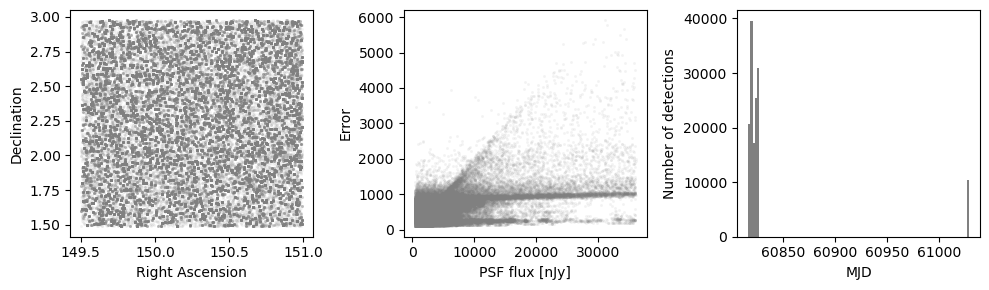

```python
fig, (ax1, ax2, ax3) = plt.subplots(1, 3, figsize=(10, 3))
ax1.plot(results['ra'][tx], results['dec'][tx],
         'o', ms=2, mew=0, alpha=0.1, color='grey')
ax1.set_xlabel('Right Ascension')
ax1.set_ylabel('Declination')
ax2.plot(results['psfFlux'][tx], results['psfFluxErr'][tx],
         'o', ms=2, mew=0, alpha=0.1, color='grey')
ax2.set_xlabel('PSF flux [nJy]')
ax2.set_ylabel('Error')
ax3.hist(results['midpointMjdTai'][tx], bins=100, color='grey')
ax3.set_xlabel('MJD')
ax3.set_ylabel('Number of detections')
plt.tight_layout()
plt.show()
```

> **Figure 2**: At left, the RA vs. Dec of diaSources as grey overlapping points, appearing darker for coordinates with many detections over time. In the center, the difference-image PSF flux vs. the flux error, for all detections in all difference-images that overlapped this tract of sky. At right, the histogram of detection dates show that most observations of the COSMOS field were done in a batch, then after a big seasonal gap, a few more were acquired.